# Data Science Project - First draft

Rebeka Éva Cook (ZN5K7X), Jeno Tóth (JSK7AT)

12/15/2021

# Our dependent variable: Price

**Our most important variable is the price.**

To gain more insight, first we can look at the **descriptive statistics** of the price variable.

```r
# Summary statistics of price:
summary(data$price)
```

```
##    Min. 1st Qu.  Median    Mean 3rd Qu.    Max.
##     0.0    70.0   110.0   169.2   184.0 10000.0
```

The **disrtibution** of price is also of interest.

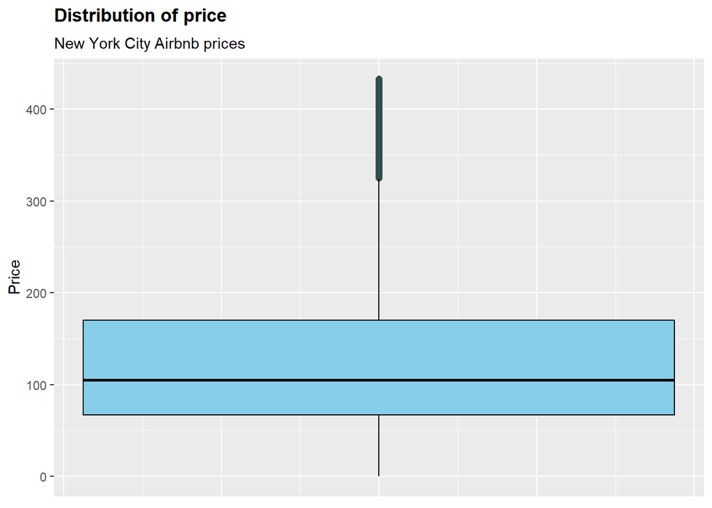

```r
# Creating box plot
ggplot(data_excl, aes(x=price)) +
  geom_boxplot(notch=TRUE) +
  coord_flip() +
  geom_boxplot(fill = "skyblue", color = "black", size=0.5, outlier.color = "darkslategrey", outlier.size = 2) +
  labs(title = expression(bold("Distribution of price")),
       subtitle = "New York City Airbnb prices",
       x = "Price") +
  theme(axis.title.x=element_blank(),
        axis.text.x=element_blank(),
        axis.ticks.x=element_blank())
```

# Examination of our explanitory variables

## Location

Our basic hypothesis is that certain areas of the city play a huge role in determining price. Consumers most likely use Airbnb’s as cheap accommodation on their holiday, in this case shorter commuting time from the centre may be more important than the housing itself. We choose Times Square as the centre.

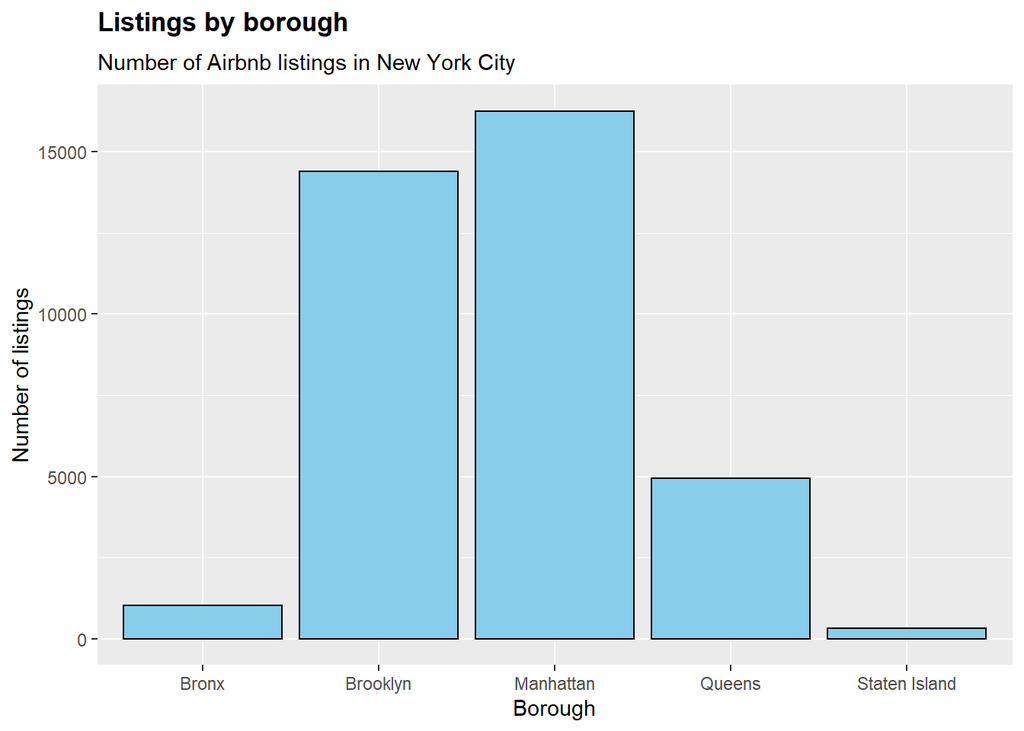

```r
# Number of listings by borough:
ggplot(data, aes(x = neighbourhood_group_cleansed)) +
  geom_bar(fill = "skyblue", color = "black", size=0.5) +
  labs(
    title = expression(bold("Listings by borough")),
    subtitle = "Number of Airbnb listings in New York City",
    y = "Number of listings",
    x = "Borough"
  )
```

We can see that the number of listings change drastically, however, this information is not very useful. Luckily, there were coordinates given, so instead, we created a new variable measuring the air line distance from the city center (in our case, Times Square)

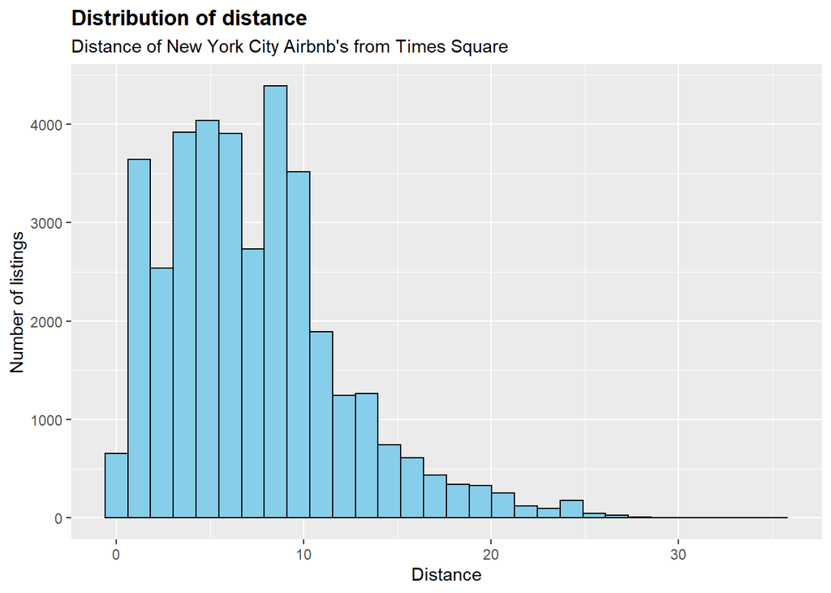

```r
# Distribution of new distance variable
ggplot(data, aes(x = distance)) +
  geom_histogram(colour="black", fill="skyblue") +
  labs(
    title = expression(bold("Distribution of distance")),
    subtitle = "Distance of New York City Airbnb's from Times Square",
    y = "Number of listings",
    x = "Distance"
  )
```

Based on this histogram, we can see that the distribution is left-peaked and right-skewed. Most listings are within 10 kilometers of Times Square.

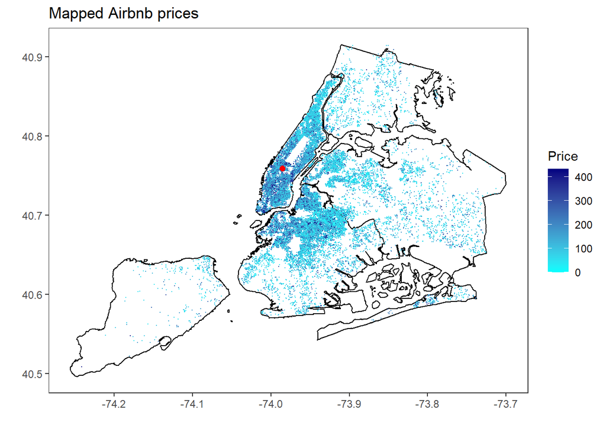

```r
# Creating heat map of price thoughout NYC
ggplot() +
  geom_polygon(data=nyc_neighborhoods_df, aes(x=long, y=lat, group=group), fill = NA, color = "black") +
  theme_bw() +
  theme(panel.grid.major = element_blank(), panel.grid.minor = element_blank()) +
  labs(
    title = "Mapped Airbnb prices",
    x = "",
    y = ""
  ) +
  geom_point(aes(x = data_excl$longitude, y = data_excl$latitude, color = data_excl$price), size = 0.1) +
  scale_colour_gradient(low = "cyan", high = "navyblue", guide = "colourbar", name = "Price") +
  geom_point(aes(x = -73.98513, y = 40.758896), color = "red", size = 2)
```

We can also check how distance affects prices.

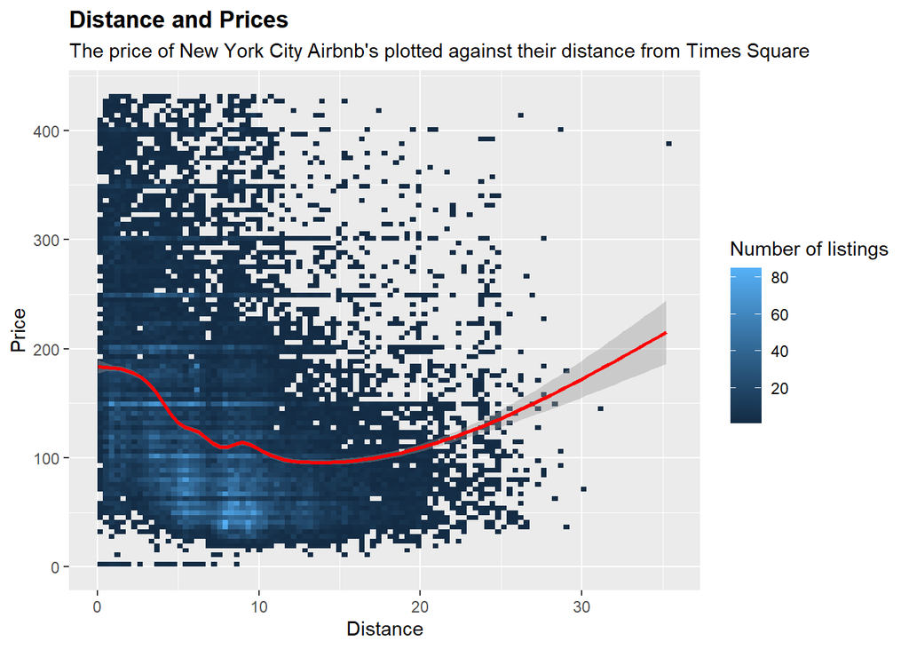

```r
# Binned scatter plot of distance and prices
ggplot(data_excl, aes(distance, price)) +
  geom_bin2d(bins = 100) +
    stat_smooth(method = "auto", col = "red", size = 1) +
    labs(
    title = expression(bold("Distance and Prices")),
    subtitle = "The price of New York City Airbnb's plotted against their distance from Times Square",
    y = "Price",
    x = "Distance",
    fill = "Number of listings"
  )
```

Based on the scatter plot above, we can see that the further we get from the centre, the cheaper the listings (for the closest 15 kilometres). For listings far away, this changes. This may be explained by the fact that such listings are not cheap accommodations used to be close to the centre, but they have other redeeming qualities dictating higher prices.

## Room type

Apart from the distance from the centre, the characteristics of the given listing also play a large roll. Therefore, We further look into these variables

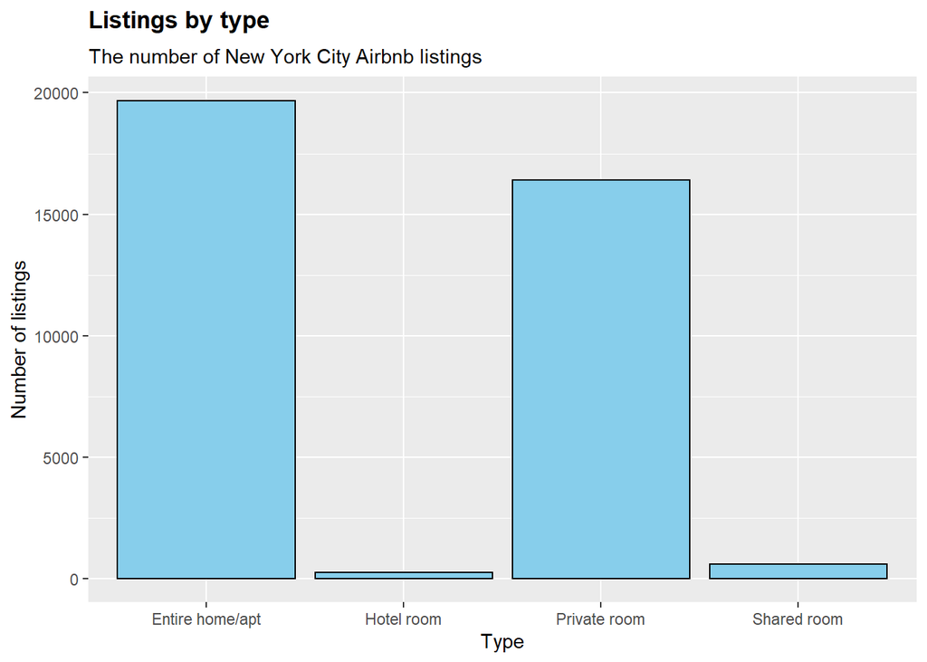

```r
# Number of listings by room type:
ggplot(data, aes(x = room_type)) +
  geom_bar(colour="black", fill="skyblue") +
  labs(
    title = expression(bold("Listings by type")),
    subtitle = "The number of New York City Airbnb listings",
    y = "Number of listings",
    x = "Type"
  )
```

```r
# Entire homes and apartments, and private rooms are most common
```

We can also examine how price is related to room type

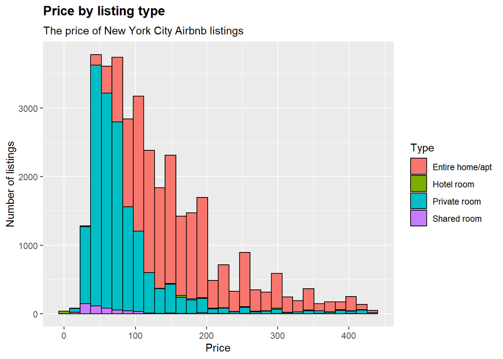

```r
# Distribution of distance

# Distribution of distance:
ggplot(data_excl, aes(x = price, fill= room_type)) +
  geom_histogram(colour="black") +
  labs(
    title = expression(bold("Price by listing type")),
    subtitle = "The price of New York City Airbnb listings",
    y = "Number of listings",
    x = "Price",
    fill = "Type"
  )
```

```r
# Clearly entire homes and apartments are the most expensive, but private rooms can also be expensive
```

## Review related variables

These can be interesting, as intuitively, the better the reviews, the higher the price could be as the listing must be better. Lets check this.

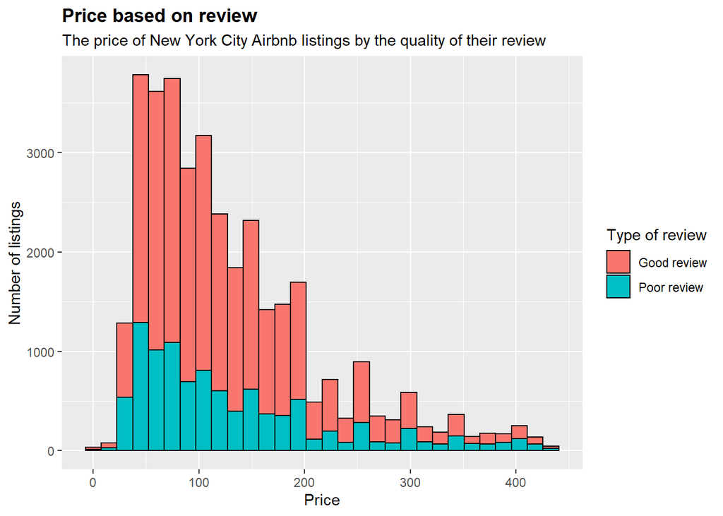

```r
# Distribution of distance:
ggplot(data_excl, aes(x = price, fill=good_review)) +
  geom_histogram(colour="black") +
  labs(
    title = expression(bold("Price based on review")),
    subtitle = "The price of New York City Airbnb listings by the quality of their review",
    y = "Number of listings",
    x = "Price",
    fill = "Type of review"
  )
```

```r
# Clearly more expensive listings had a higher price
```

## Host-characteristics

```r
host <- lm(data = data_variables, price ~ host_since_days + host_acceptance_rate + host_is_professional + sentiment_score)
stargazer(host,type="text")
```

```
##
## ================================================
##                          Dependent variable:
##                      ---------------------------
##                                 price
## ------------------------------------------------
## host_since_days               -0.011***
##                                (0.002)
##
## host_acceptance_rate          0.267***
##                                (0.067)
##
## host_is_professional          10.160***
##                                (3.209)
##
## sentiment_score               3.865***
##                                (0.372)
##
## Constant                     144.126***
##                                (7.085)
##
## ------------------------------------------------
## Observations                   36,923
## R2                              0.005
## Adjusted R2                     0.005
## Residual Std. Error     298.312 (df = 36918)
## F Statistic           50.886*** (df = 4; 36918)
## ================================================
## Note:                *p<0.1; **p<0.05; ***p<0.01
```

## Some linear regression models for insight

```r
# Running linear regression models with different variables:
reg_basic <- lm(data=data_variables,price ~ distance)
reg_controls <- lm(data = data_variables, price ~ accommodates + beds + bedrooms +
                          bathrooms + is_entire_home_apt + is_private_room + is_hotel_room)
reg_host <- lm(data = data_variables, price ~ host_since_days + host_acceptance_rate +
                      host_listings_count + sentiment_score)
reg_all <- lm(data = data_variables, price ~ .)

# Presenting all in a table
stargazer(reg_basic, reg_controls, reg_all,type="text")
```

```
##
## ========================================================================================================
##                                                       Dependent variable:
##                        ---------------------------------------------------------------------------------
##                                                              price
##                                   (1)                        (2)                         (3)
## --------------------------------------------------------------------------------------------------------
## host_since_days                                                                       -0.010***
##                                                                                        (0.002)
##
## host_response_rate                                                                     -0.030
##                                                                                        (0.079)
##
## host_acceptance_rate                                                                  0.229***
##                                                                                        (0.069)
##
## host_is_superhost                                                                       4.240
##                                                                                        (4.013)
##
## host_listings_count                                                                   0.066***
##                                                                                        (0.007)
##
## host_has_profile_pic                                                                   -16.943
##                                                                                       (20.726)
##
## host_identity_verified                                                               -10.912***
##                                                                                        (3.869)
##
## distance                       -8.653***                                              -8.251***
##                                 (0.325)                                                (0.322)
##
## sentiment_score                                                                       1.431***
##                                                                                        (0.360)
##
## host_is_professional                                                                   -1.197
##                                                                                        (3.069)
##
## accommodates                                              35.406***                   35.236***
##                                                            (1.283)                     (1.274)
##
```

[output cut: 23 more lines]

```
##
## is_shared_room
##
##
## Constant                       232.320***                 -63.425***                   47.516*
##                                 (2.831)                    (12.440)                   (25.099)
##
## --------------------------------------------------------------------------------------------------------
## Observations                     36,923                     36,923                     36,923
## R2                               0.019                      0.110                       0.138
## Adjusted R2                      0.019                      0.110                       0.137
## Residual Std. Error       296.296 (df = 36921)       282.152 (df = 36915)       277.826 (df = 36903)
## F Statistic            707.406*** (df = 1; 36921) 654.358*** (df = 7; 36915) 310.258*** (df = 19; 36903)
## ========================================================================================================
## Note:                                                                        *p<0.1; **p<0.05; ***p<0.01
```

```r
# Comparing the models by the Akaike Infomation Criterion
AIC(reg_basic, reg_controls, reg_host, reg_all) # clearly the linear regression model with all variables is the best.
```

```
##              df      AIC
## reg_basic     3 525071.1
## reg_controls  9 521465.1
## reg_host      6 525415.6
## reg_all      21 520336.0
```

```r
#However, models must be examined further
```

## Predictions

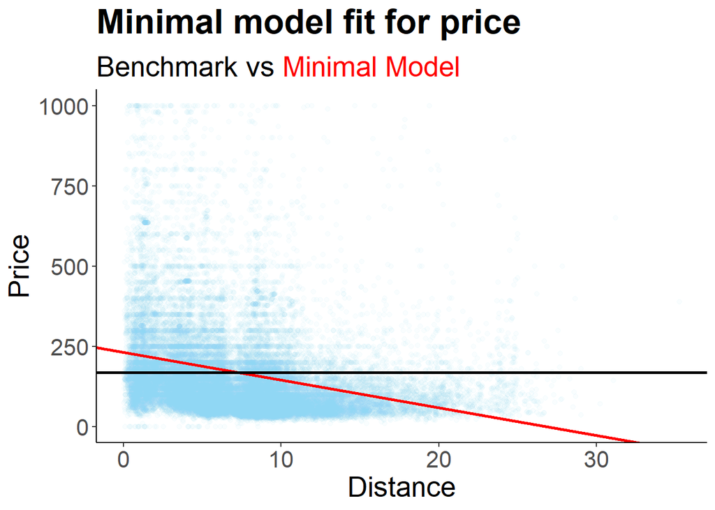

```r
# Plotting the baseline model
ggplot(data_variables, aes(x = distance, y = price)) +
    geom_point(alpha = 0.05, color="skyblue") +
    geom_abline(intercept = intercept, slope = slope, color = "red", size = 1) +
    geom_hline(yintercept = mean(predictions_basic_model), color = "black", size = 1) +
    labs(
      title = expression(bold("Minimal model fit for price")),
      subtitle = "<span style = 'color: black;'>Benchmark</span> vs <span style = 'color: red;'>Minimal Model</span>",
      y = "Price",
      x = "Distance"
    ) +
    ylim(0,1000) +
    theme_classic() +
    theme(text = element_text(size = 20)) +
    theme(plot.subtitle = ggtext::element_markdown())
```

**Trying different predictive models and comparing them based on their RMSE**

We hypothesise that the ridge regression will provide better predictions in our case since most predictors should impact price. But we will try lasso nevertheless, to be thorough.

```r
# Comparing RMSE's
rmse
```

```
##                   Linear regression Ridge regression Lasso regression
## All predictors             244.7244         244.6760         244.6402
## Room predictors            245.7840         245.7458         245.7297
## Host predictors            262.9029         262.8865         262.8945
## Review predictors          262.9824         262.9692         262.9776
```

**The model with the prediction which minimizes the RMSE is the lasso regression including all explanitory variables**

Therefore, lets visualize this model to see where it predicts best

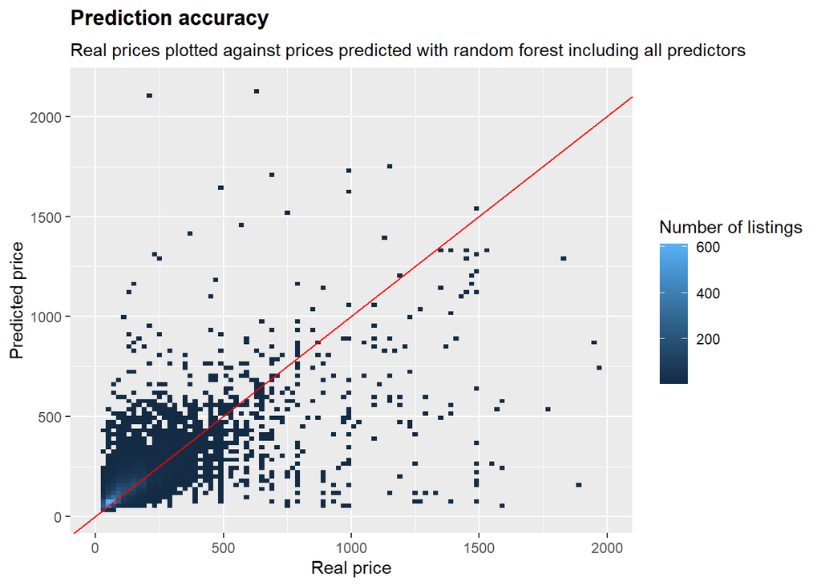

```r
# Plotting predicted values on observed values of price
ggplot(data_test, aes(x = price, y =  rf_predict1)) +
  geom_bin2d(bins = 100) +
    geom_abline(slope=1,color="red") +
    labs(
    title = expression(bold("Prediction accuracy")),
    subtitle = "Real prices plotted against prices predicted with random forest including all predictors",
    y = "Predicted price",
    x = "Real price",
    fill = "Number of listings"
  ) +
  xlim(0,2000)
```

```r
# The higher the price, the less accurate the prediction. This model is best for the average Airbnb user.
```

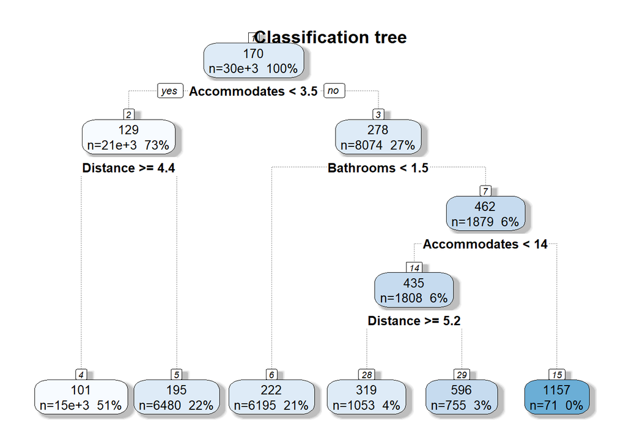

```r
# Creating decision tree
fancyRpartPlot(price_tree, main = "Classification tree", sub = "", palettes = "Blues")
```